# STAT385 Notes Week 3

Jonathan Bonaguro

Week 3

## Monday, Feb. 3, 2020

#### Changing values in place

To modify a value within an R object:

- First, describe the value you wish to modify
- Use the assignment operator `<-` to overwrite those values
- R will update the selected values **i the original object**

```r
x <- c(0,0,0,0,0)
x[1] <- 100
x
```

```
## [1] 100   0   0   0   0
```

To change multiple values at once, make sure the number of **new values** equals the number of **selected values**:

```r
x[c(1,3,5)] <- c(5,5,5)
x
```

```
## [1] 5 0 5 0 5
```

```r
x[4:6] <- x[4:6] + 1
x
```

```
## [1]  5  0  5  1  6 NA
```

Just like populating vectors, R will repeat itself until it can’t anymore.

```r
x[1:2] <- c(2)
x
```

```
## [1]  2  2  5  1  6 NA
```

```r
x[1:2] <- c(100,100,100)
x
```

```
## [1] 100 100   5   1   6  NA
```

#### Looking at Data Frames

Let’s add a new column to `deck`:

```r
deck <- read.csv("https://nkha149.github.io/stat385-sp2020/files/data/cards.csv")
deck$new_column <- 1:52
deck
```

| face | suit | value | new_column |
| --- | --- | --- | --- |
| king | spades | 13 | 1 |
| queen | spades | 12 | 2 |
| jack | spades | 11 | 3 |
| ten | spades | 10 | 4 |
| nine | spades | 9 | 5 |
| eight | spades | 8 | 6 |
| seven | spades | 7 | 7 |
| six | spades | 6 | 8 |
| five | spades | 5 | 9 |
| four | spades | 4 | 10 |

[output cut: 42 more lines]

Lets change some values:

```r
deck[c(13, 26, 39, 52), 3] <- 14
deck
```

| face | suit | value | new_column |
| --- | --- | --- | --- |
| king | spades | 13 | 1 |
| queen | spades | 12 | 2 |
| jack | spades | 11 | 3 |
| ten | spades | 10 | 4 |
| nine | spades | 9 | 5 |
| eight | spades | 8 | 6 |
| seven | spades | 7 | 7 |
| six | spades | 6 | 8 |
| five | spades | 5 | 9 |
| four | spades | 4 | 10 |

[output cut: 42 more lines]

#### Logical Operators

```r
1 > 2
```

```
## [1] FALSE
```

```r
1 > c(0:2)
```

```
## [1]  TRUE FALSE FALSE
```

```r
c(1,2,3) == c (3,2,1)
```

```
## [1] FALSE  TRUE FALSE
```

```r
1 %in% c(3:5)
```

```
## [1] FALSE
```

The operators are standard. A different one, `%in%` looks if values are in a group. This operator does not follow element-wise execution. `%in%` independently tests whether each value is somewhere in the vector.

```r
c(1:4) %in% c(3:5)
```

```
## [1] FALSE FALSE  TRUE  TRUE
```

**Note:** `=` is an assignment operator like `<-`. Make sure to use `==`.

#### Using Logical Operator for Subsetting

- Let’s say in a certain game, aces receive the highest value, say 14.
- Modify the values in `deck` to follow this rule
- What are the values of the aces in `deck` right now?

```r
deck$face
```

```
##  [1] king  queen jack  ten   nine  eight seven six   five  four  three two
## [13] ace   king  queen jack  ten   nine  eight seven six   five  four  three
## [25] two   ace   king  queen jack  ten   nine  eight seven six   five  four
## [37] three two   ace   king  queen jack  ten   nine  eight seven six   five
## [49] four  three two   ace
## Levels: ace eight five four jack king nine queen seven six ten three two
```

```r
deck$face == "ace"
```

```
##  [1] FALSE FALSE FALSE FALSE FALSE FALSE FALSE FALSE FALSE FALSE FALSE FALSE
## [13]  TRUE FALSE FALSE FALSE FALSE FALSE FALSE FALSE FALSE FALSE FALSE FALSE
## [25] FALSE  TRUE FALSE FALSE FALSE FALSE FALSE FALSE FALSE FALSE FALSE FALSE
## [37] FALSE FALSE  TRUE FALSE FALSE FALSE FALSE FALSE FALSE FALSE FALSE FALSE
## [49] FALSE FALSE FALSE  TRUE
```

Columns that say `TRUE` are aces. Let’s subet.

```r
deck[deck$face == "ace",]
```

|  | face | suit | value | new_column |
| --- | --- | --- | --- | --- |
| 13 | ace | spades | 14 | 13 |
| 26 | ace | clubs | 14 | 26 |
| 39 | ace | diamonds | 14 | 39 |
| 52 | ace | hearts | 14 | 52 |

Now, let’s update the value for the aces to be 14!

```r
deck[deck$face == "ace", c("value")] <- 14
deck[deck$face == "ace",]
```

|  | face | suit | value | new_column |
| --- | --- | --- | --- | --- |
| 13 | ace | spades | 14 | 13 |
| 26 | ace | clubs | 14 | 26 |
| 39 | ace | diamonds | 14 | 39 |
| 52 | ace | hearts | 14 | 52 |

#### Boolean Operators

- And `&`
- Or `|`
- Exclusive or `xor`
- Not `!`
- Any `any`
- All `all`

To use Boolean operator, place it between two *complete* logical tests.

```r
a <- c(1:3)
b <- c(1:3)
c <- c(1,2,4)
a == b
```

```
## [1] TRUE TRUE TRUE
```

```r
c == b
```

```
## [1]  TRUE  TRUE FALSE
```

```r
a == c
```

```
## [1]  TRUE  TRUE FALSE
```

#### Excercise 1

Read in data from csv:

```r
hearts_deck <- read.csv("https://nkha149.github.io/stat385-sp2020/files/data/cards.csv")
```

In a new game called **Hearts**, every card has the value `0` except for the suit Hearts and the Queen of spades. Set up the deck in this way:

- Hearts all have value `1`
- The Queen of Spades has value `13`
- Save data as Data Frame `hearts_deck`

```r
# Set all values in deck equal to 0
hearts_deck$value <- 0
hearts_deck[hearts_deck$suit == "hearts", 3] <- 1
hearts_deck[hearts_deck$suit == "spades" & hearts_deck$face == "queen", 3] <- 13
hearts_deck
```

| face | suit | value |
| --- | --- | --- |
| king | spades | 0 |
| queen | spades | 13 |
| jack | spades | 0 |
| ten | spades | 0 |
| nine | spades | 0 |
| eight | spades | 0 |
| seven | spades | 0 |
| six | spades | 0 |
| five | spades | 0 |
| four | spades | 0 |

[output cut: 42 more lines]

Ta da!

## Friday, Feb. 7, 2020

#### `if` Statement

- an `if` statement tells R to do a certain task for a certain case
- `condition` object should be a logical test
- if `condition` is `TRUE`
  - R will run all the code that appears in the `{}` following the `if` statement
- if `condition` is `FALSE`
  - R will skip the curly brackets

```r
num <- -2

if (num < 0) {
  num <- num * -1
}

num
```

```
## [1] 2
```

```r
num <- 4

if (num < 0) {
  num <- num * -1
}

num
```

```
## [1] 4
```

#### `else` statement

- `else` tells R what to do when the condition is `FALSE`

```r
my_round <- function(a){
  decimal <- a - trunc(a)
  if (decimal >= 0.5) {
    a <- trunc(a) + 1
  } else {
    a <- trunc(a)
  }
  return(a)
}
my_round(3.14)
```

```
## [1] 3
```

#### `if else` ladder

```r
who_win <- function(a, b){
  if (a > b) {
    print("A wins!")
  } else if (a <b) {
    print("B wins!")
  } else {
    print("Tie.")
  }
}
who_win(3, 1)
```

```
## [1] "A wins!"
```

```r
who_win(5, 10)
```

```
## [1] "B wins!"
```

```r
who_win(3, 3)
```

```
## [1] "Tie."
```

#### Histograms

- Basic histogram using `hist()`
  - Change the plot title with `main =`
  - Change x-axis label with `xlab=`

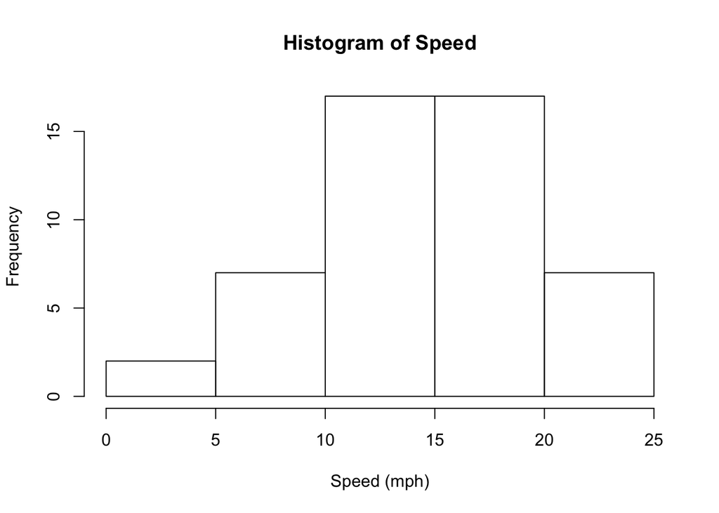

```r
hist(x = cars$speed, main = "Histogram of Speed", xlab = "Speed (mph)")
```

- Change histogram from frequency to probability using `probability = TRUE`

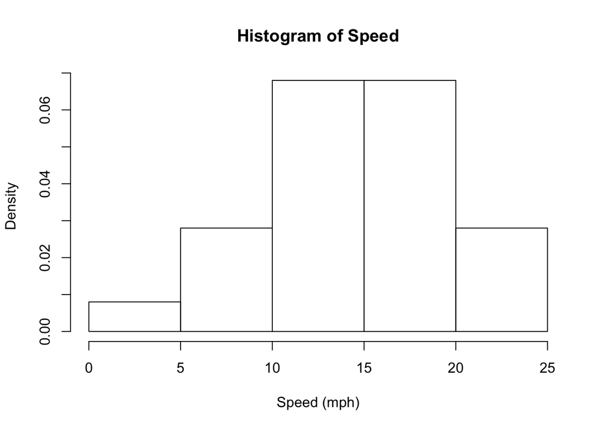

```r
hist(x = cars$speed, main = "Histogram of Speed", xlab = "Speed (mph)", probability = TRUE)
```

- Change the break points in the histogram celss using `breaks =`
  - Use `seq()` to compute vector of breakpoints

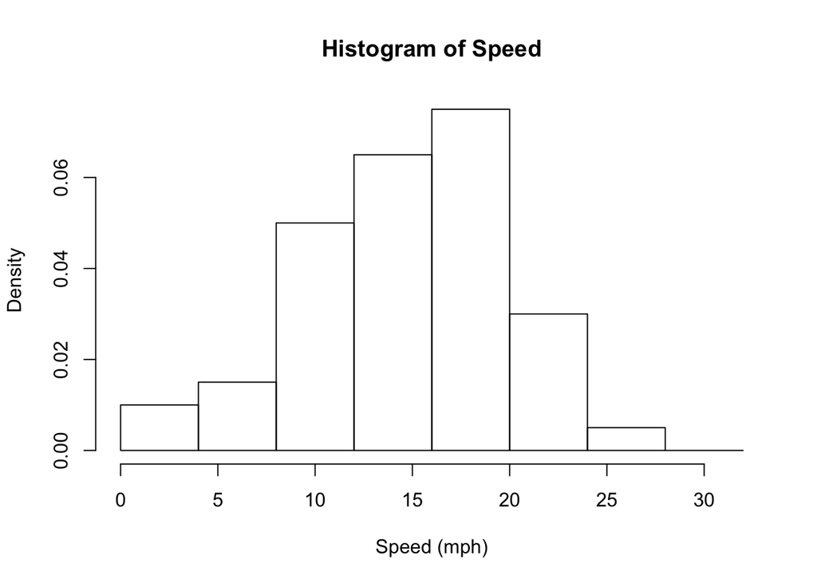

```r
hist(x = cars$speed, main = "Histogram of Speed", xlab = "Speed (mph)", probability = TRUE, breaks = seq(from = 0, to = 32, by = 4))
```

- Provide `breaks =` a single number to specify breaks

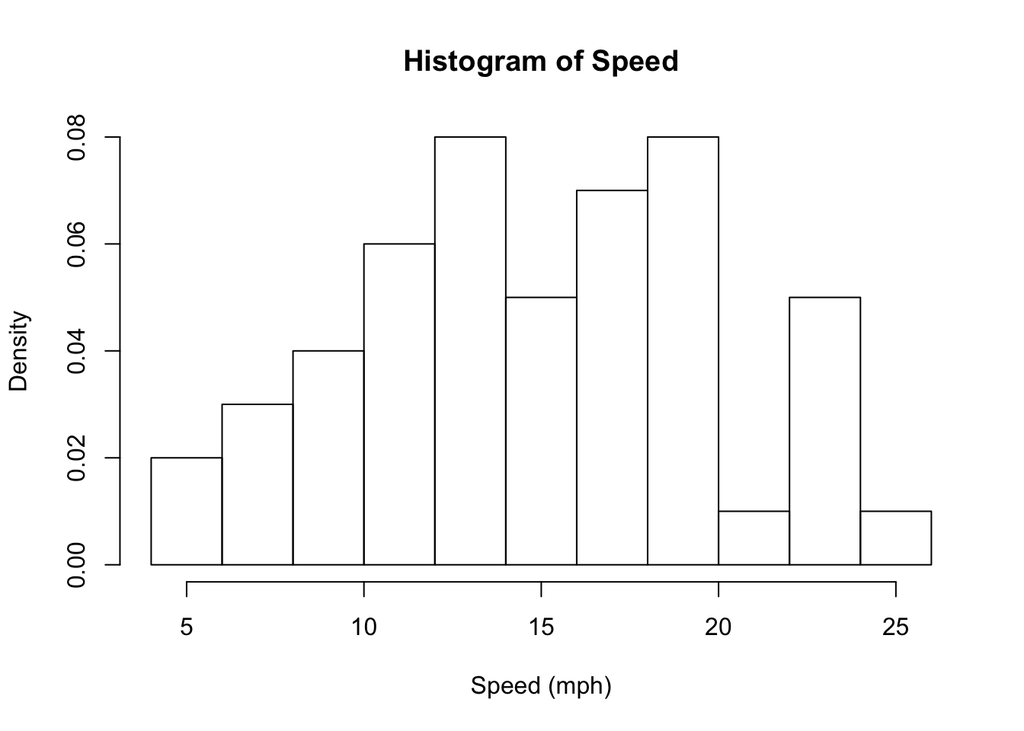

```r
hist(x = cars$speed, main = "Histogram of Speed", xlab = "Speed (mph)", probability = TRUE, breaks = 10)
```

- Color inside of bins with `col =`

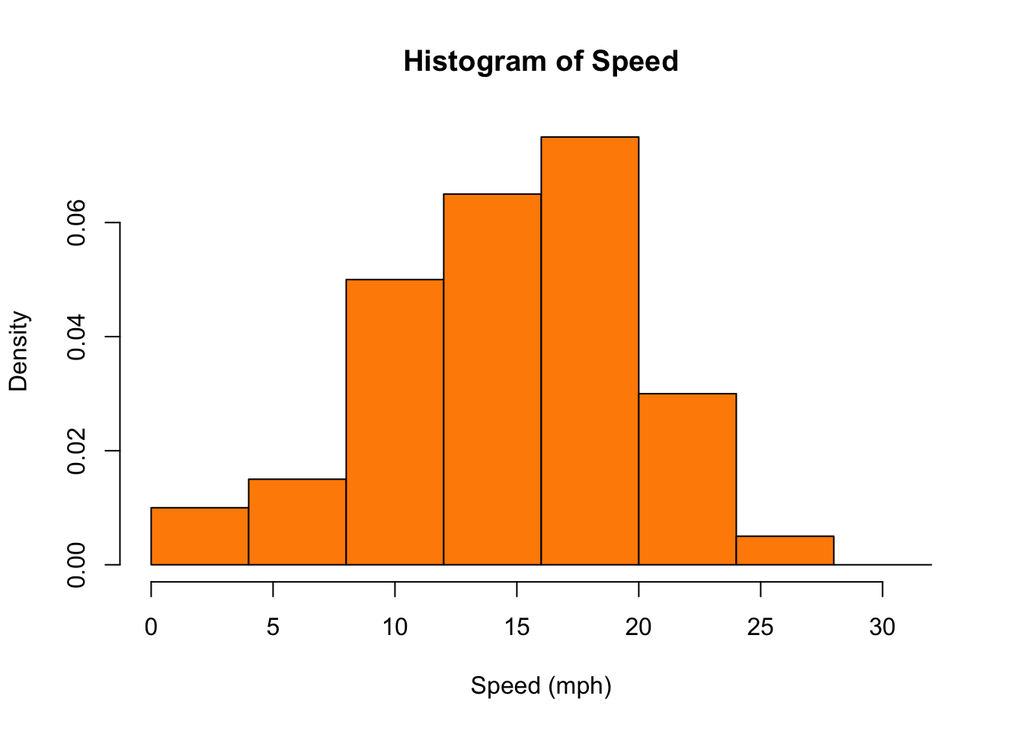

```r
hist(x = cars$speed, main = "Histogram of Speed", xlab = "Speed (mph)", probability = TRUE, breaks = seq(from = 0, to = 32, by = 4), col = "darkorange")
```

- Color border of histogram using `border =`

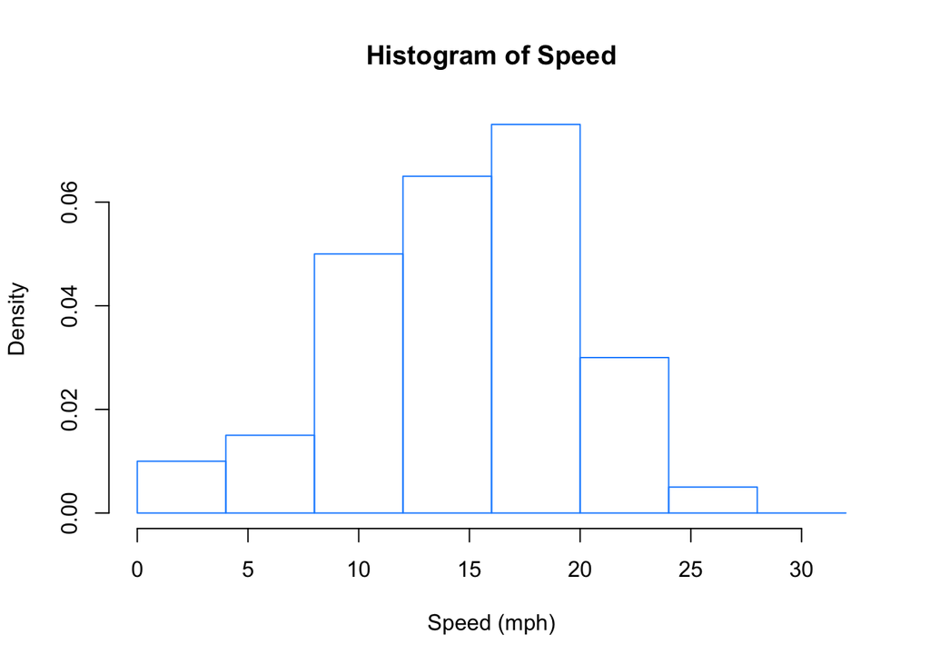

```r
hist(x = cars$speed, main = "Histogram of Speed", xlab = "Speed (mph)", probability = TRUE, breaks = seq(from = 0, to = 32, by = 4), border = "dodgerblue")
```

- Add box and grid using `box()` and `grid`

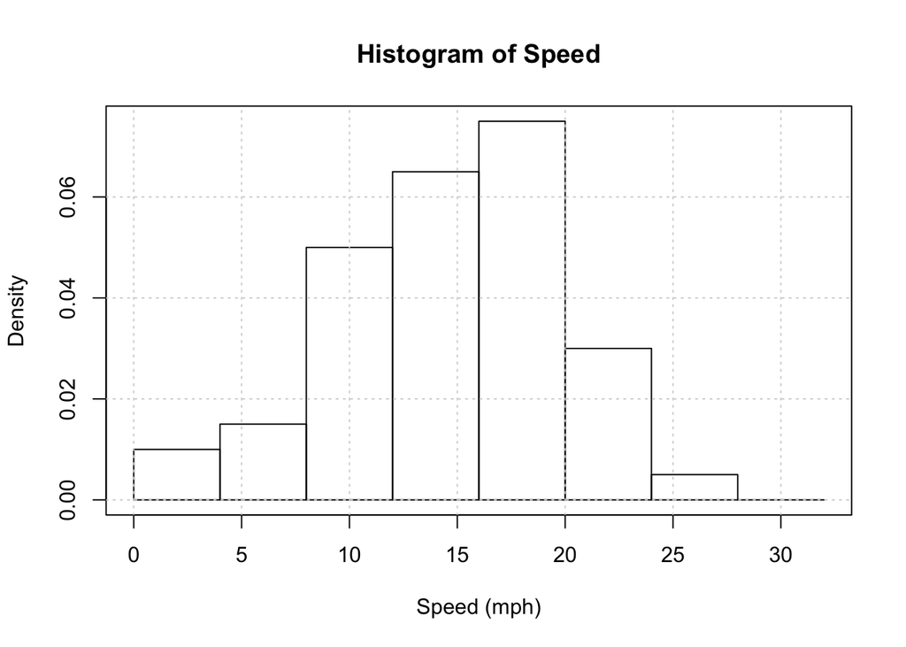

```r
hist(x = cars$speed, main = "Histogram of Speed", xlab = "Speed (mph)", probability = TRUE, breaks = seq(from = 0, to = 32, by = 4))
box()
grid()
```

#### Boxplot

- Used for exploratory data analysis

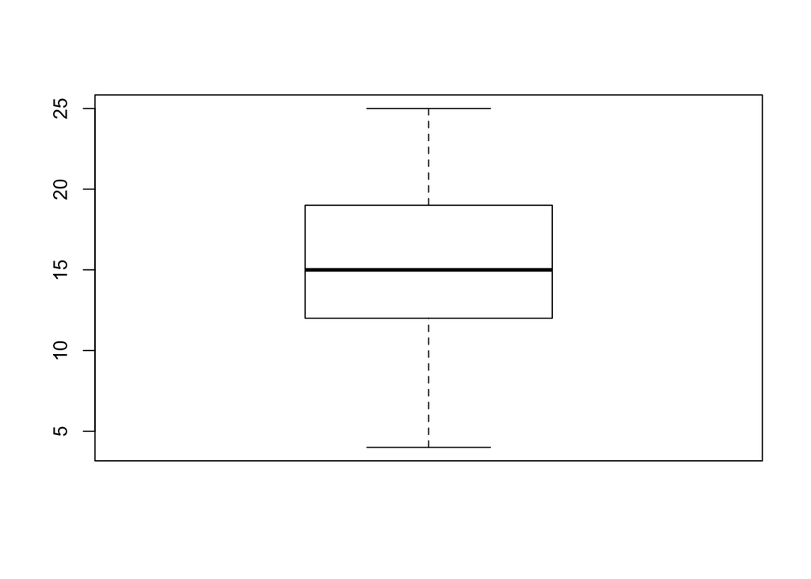

```r
boxplot(x = cars$speed)
```

- Add title and axis label

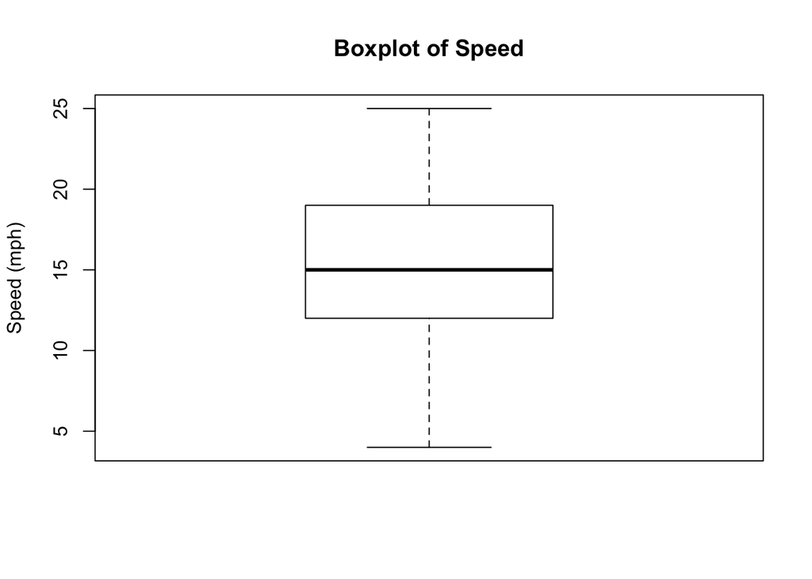

```r
boxplot(x = cars$speed, main = "Boxplot of Speed", ylab = "Speed (mph)")
```

- Rotate plot using `horizontal = TRUE`

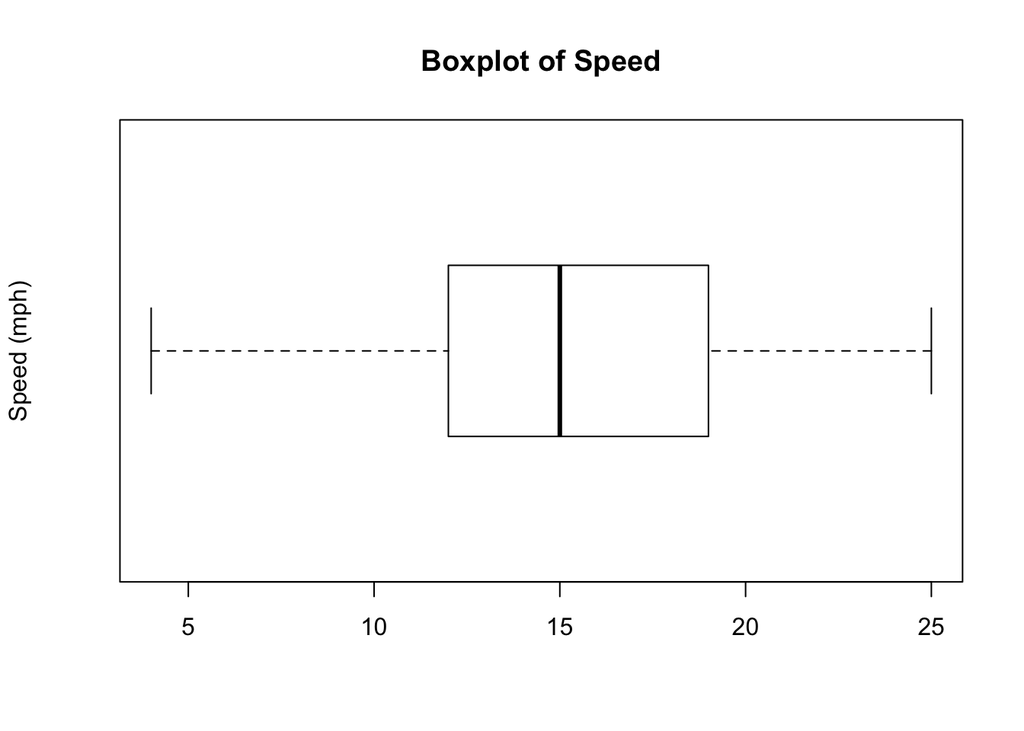

```r
boxplot(x = cars$speed, main = "Boxplot of Speed", ylab = "Speed (mph)", horizontal = TRUE)
```

#### Scatterplot

- Use `plot()` to make a Scatterplot

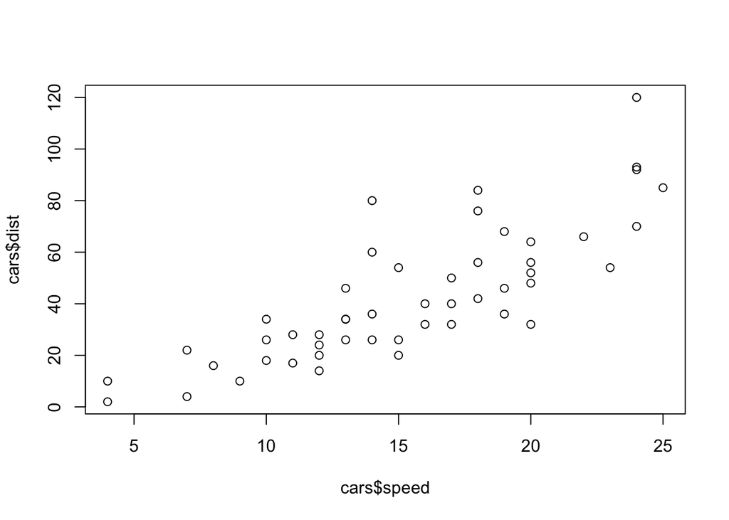

```r
plot(x = cars$speed, y = cars$dist)
```

- Add title and labels

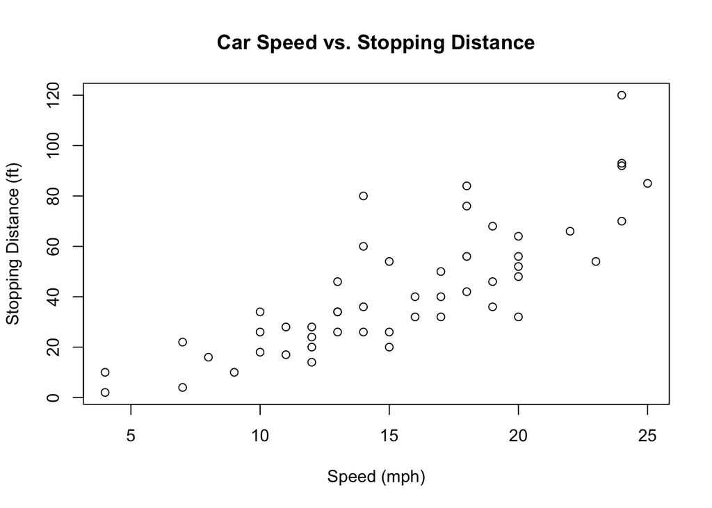

```r
plot(x = cars$speed, y = cars$dist, main = "Car Speed vs. Stopping Distance", xlab = "Speed (mph)", ylab = "Stopping Distance (ft)")
```

- Add color and grid. Change the plotting symbol using `pch =`

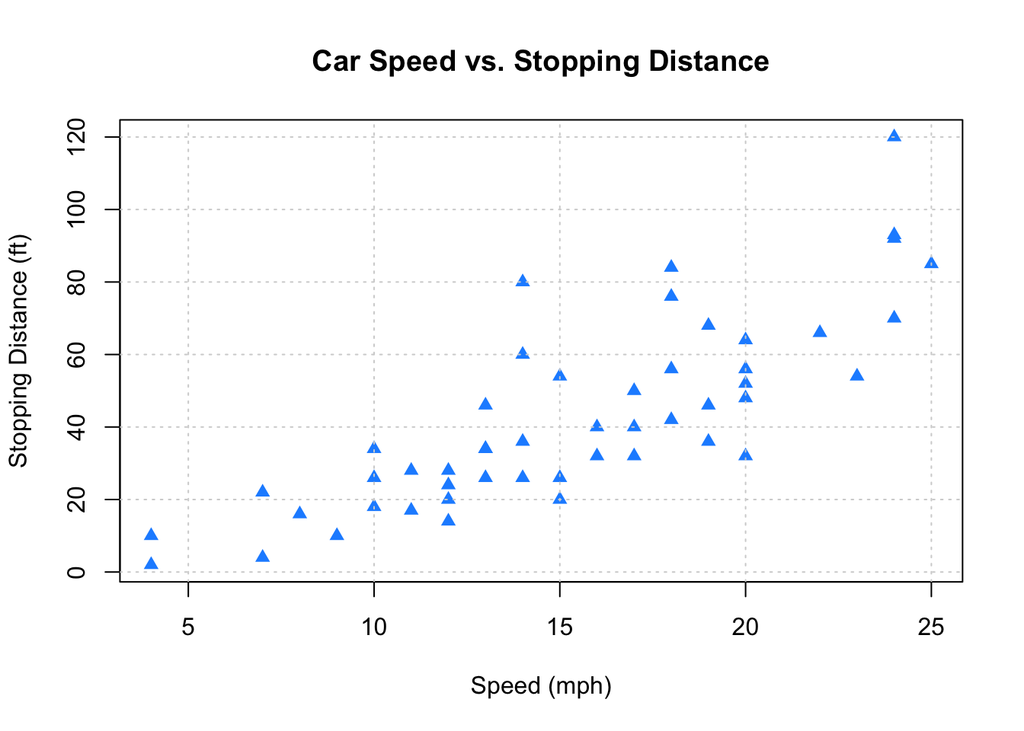

```r
plot(x = cars$speed, y = cars$dist, main = "Car Speed vs. Stopping Distance", xlab = "Speed (mph)", ylab = "Stopping Distance (ft)", col = "dodgerblue", pch = 17)
grid()
```

- Let’s try to change the scale on the axis using `xlim =` and `ylim =`

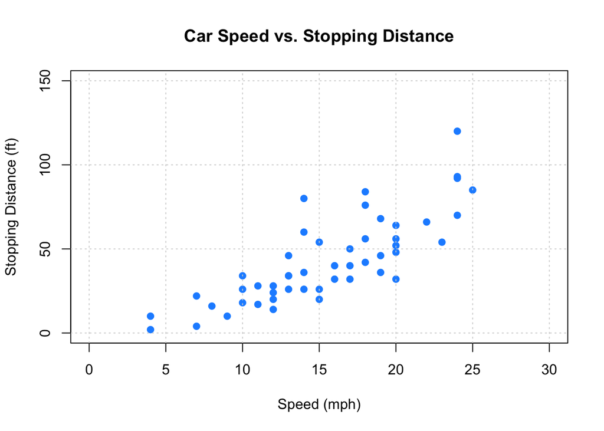

```r
plot(x = cars$speed, y = cars$dist, main = "Car Speed vs. Stopping Distance", xlab = "Speed (mph)", ylab = "Stopping Distance (ft)", col = "dodgerblue", pch = 19, xlim = c(0, 30), ylim = c(0, 150))
grid()
```

#### Play around with plotting

- Plot histogram of `eruptions` in dataset `faithful`

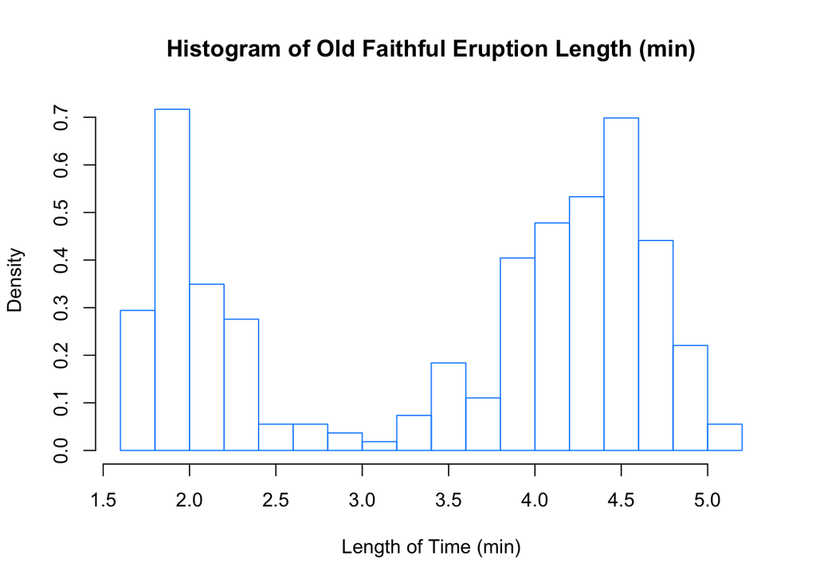

```r
hist(faithful$eruptions, main = "Histogram of Old Faithful Eruption Length (min)", xlab = "Length of Time (min)", breaks = 20, probability = TRUE, border = "dodgerblue")
```

- Plot a scatterplot between the eruption time and waiting time to the next eruption

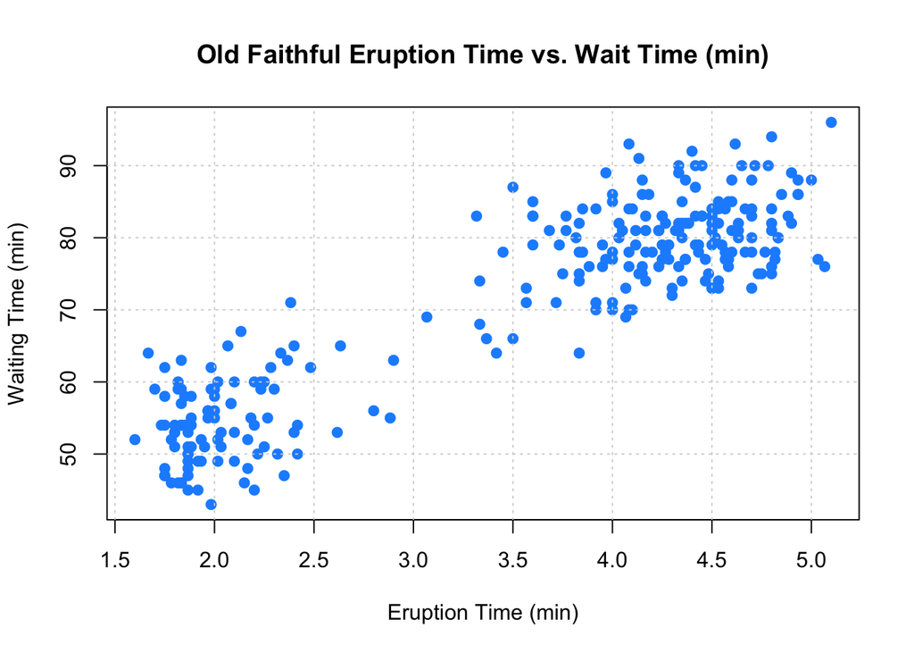

```r
plot(x = faithful$eruptions, y = faithful$waiting, main = "Old Faithful Eruption Time vs. Wait Time (min)", xlab = "Eruption Time (min)", ylab = "Waiting Time (min)", col = "dodgerblue", pch = 19)
grid()
```

- Another way to plot is with `formula =` and `data =`

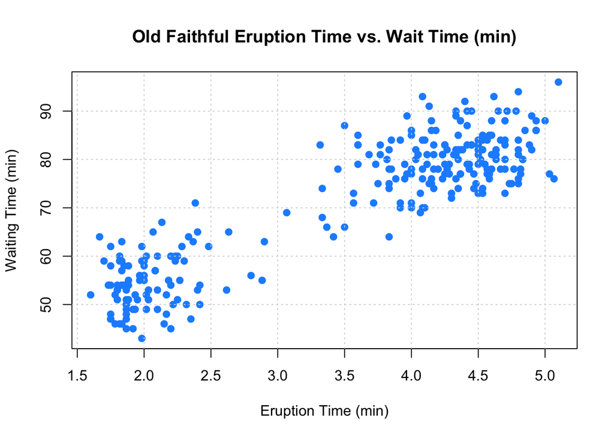

```r
plot(formula = waiting ~ eruptions, data = faithful, main = "Old Faithful Eruption Time vs. Wait Time (min)", xlab = "Eruption Time (min)", ylab = "Waiting Time (min)", col = "dodgerblue", pch = 19)
grid()
```

- This is a preferred method for plotting, especially when we get to regressions. This specifies that `waiting` is being plotted as a function of `eruption`